# 三节课-R语言-房价数据分析

作者：王司腾

# 三节课R语言数据分析练习

三节课提供了相关的房价数据，我们可以利用R语言对其进行**数据可视化**，对影响房价的因素进行更直观的分析。

## 第一步：**数据挖掘**（数据获取）

```r
setwd("/Users/siteng/Documents/GitHub/SanJieKe-R-project")
#设置正确的文档读取路径
hpData<- read.csv("房价数据.csv", fileEncoding = "GBK")
#hpData表示house price data房价数据
```

## 第二步：**数据清洗**

### 首先我们可以通过head(), tail(), summary(), str()等概览数据的结构及类型

```
## 'data.frame':    164 obs. of  11 variables:
##  $ 产权      : int  70 70 70 70 70 70 70 70 70 70 ...
##  $ 价格.万元.: int  123 500 340 360 670 235 388 700 250 520 ...
##  $ 区域      : Factor w/ 1 level "西湖区": 1 1 1 1 1 1 1 1 1 1 ...
##  $ 小区      : Factor w/ 27 levels "城北商贸园","都市阳光和苑",..: 15 15 15 15 15 15 15 15 15 15 ...
##  $ 年限      : Factor w/ 17 levels "1996年建","1997年建",..: 15 9 15 6 15 15 3 12 15 12 ...
##  $ 楼型      : Factor w/ 4 levels "板楼","板塔结合",..: 4 4 2 1 1 1 1 1 1 1 ...
##  $ 挂牌时间  : int  201807 201904 201903 201902 201905 201710 201901 201811 201809 201810 ...
##  $ 朝向      : Factor w/ 9 levels "东","东 南","东 南 北",..: 5 6 6 5 6 5 5 5 6 5 ...
##  $ 楼层      : Factor w/ 53 levels "低楼层/共11层",..: 33 27 46 35 30 44 50 8 24 8 ...
##  $ 装修情况  : Factor w/ 7 levels "简装","精装",..: 4 2 5 5 3 6 4 5 5 4 ...
##  $ 面积.平米.: num  89.5 325.2 139.5 142.5 259.3 ...
```

```r
hpData$价格.万元. <- as.numeric(hpData$价格.万元.)
hpData$面积.平米. <- as.numeric(hpData$面积.平米.)
#将“价格（万元）”、“面积（平米）”变量变为数值型
```

### 使用dplyr包创建新变量“单价”

```r
newhpData <- hpData%>%
mutate(单价=价格.万元./面积.平米.)%>%
arrange(挂牌时间)
#按照“挂牌时间”升序排序
```

### 再次使用str()检查处理后的dataframe

[output not shown]

### 进一步数据清洗（异常值处理）：

```r
IQR <- quantile(newhpData$单价)[4]-quantile(newhpData$单价)[2] #定义IQR
extreme.lower.bound <- quantile(newhpData$单价)[2]-3*IQR
extreme.upper.bound <- quantile(newhpData$单价)[4]+3*IQR
#定义极度异常值的边界
mild.lower.bound <- quantile(newhpData$单价)[2]-1.5*IQR
mild.upper.bound <- quantile(newhpData$单价)[4]+1.5*IQR
#定义轻度异常值的边界
extreme.new.hpData <- newhpData[newhpData$单价<=extreme.upper.bound & newhpData$单价 >= extreme.lower.bound,]
mild.new.hpData <- newhpData[newhpData$单价<=mild.upper.bound & newhpData$单价 >= mild.lower.bound,]
newhpData <- mild.new.hpData
#剔除轻度异常值和极度异常值
```

异常值具体方法可参照：https://shimo.im/docs/EDIrOtdOpM4FGsBA/read

## 第三步：**数据探索**（数据可视化）:

利用ggplot2包对房价和各可能因素进行制图

### 绘制箱型图展示不同楼型房屋单价的分布情况

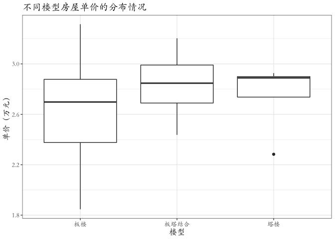

```r
g1 <- ggplot(newhpData,aes(楼型,单价))
g1 + geom_boxplot() +
  # 改变坐标名称
  labs(x="楼型") +
  labs(y="单价（万元）") +
  # 修改题目名称
  labs(title="不同楼型房屋单价的分布情况")+
  theme_bw(base_family = "Avenir",base_size = 10) +
  theme(text=element_text(family="STKaiti",size=12))
```

#### 分析与结论：

1. 从整体来说，板楼的单价<板塔结合的单价<塔楼的单价，单其中**塔楼**的单价数据少，存在异常情况，不具参考性；
2. **板楼**的每平方米的单价区间较大，最低在1.8万元/平米，最高3.2万元/平米；**板塔结合型**单价较稳定。

### 通过散点图展示房屋单价与其他变量之间的关系（单价与面积）

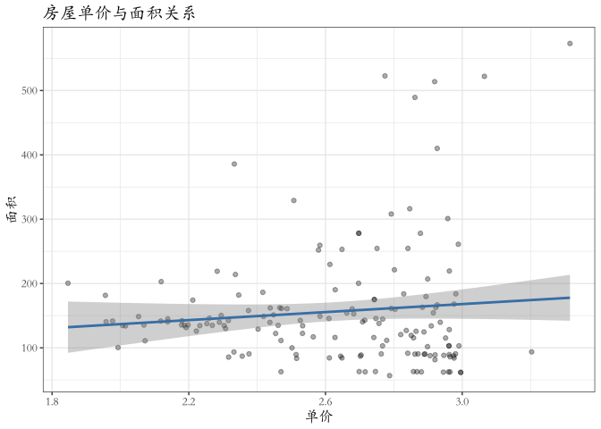

```r
g2 <- ggplot(newhpData,aes(单价,面积.平米.))
g2+geom_point(alpha=1/3)+
  # 用线性回归拟合数据，颜色为steelblue
  geom_smooth(method="lm",col="steelblue") +
  # 个性化设置
  theme_bw(base_family = "Avenir",base_size = 10) +
  theme(text=element_text(family="STKaiti",size=12)) +
  # 横坐标为“单价”
  labs(x="单价") +
  # 纵坐标为“面积”
  labs(y="面积") +
  # 设置标题
  labs(title="房屋单价与面积关系")
```

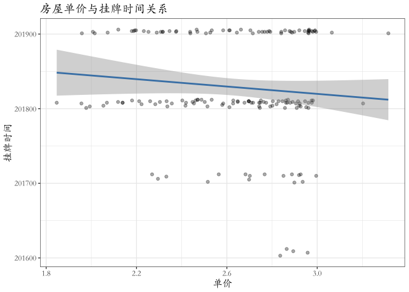

```r
g3 <- ggplot(newhpData,aes(单价,挂牌时间))
g3 + geom_point(alpha=1/3)+
  # 用线性回归拟合数据，颜色为steelblue
  geom_smooth(method="lm",col="steelblue") +
  # 个性化设置
  theme_bw(base_family = "Avenir",base_size = 10) +
  theme(text=element_text(family="STKaiti",size=12)) +
  # 横坐标为“单价”
  labs(x="单价") +
  # 纵坐标为“面积”
  labs(y="挂牌时间") +
  # 设置标题
  labs(title="房屋单价与挂牌时间关系")
```

#### 分析与结论：

1. 房屋单价与挂牌时间不具线性相关性，即房屋单价与挂牌时间的早晚没有直接的关系;
2. 2016年房屋的单价在**2.8万至3万**区间，高房价，房价上涨;
3. 2017年房屋的单价在**2.2万至3万**区间，高房价，房价上涨;
4. 2018年和2019年房屋的单价分布均匀，在1.8万-3万区间，房价有所回落。  
   ### 朝向等的关系:

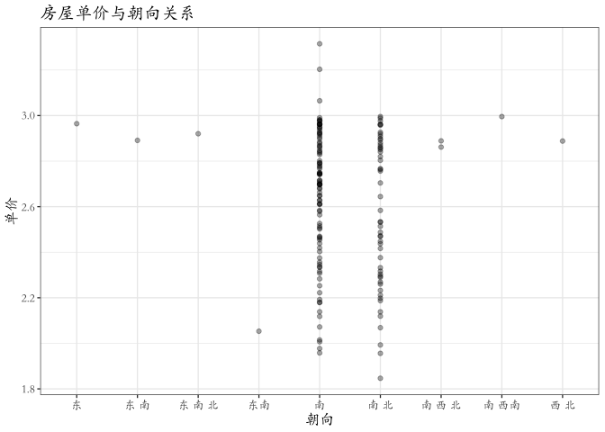

```r
g4 <- ggplot(newhpData,aes(朝向,单价))
g4 + geom_point(alpha=1/3)+
  # 用线性回归拟合数据，颜色为steelblue
  geom_smooth(method="lm",col="steelblue") +
  # 个性化设置
  theme_bw(base_family = "Avenir",base_size = 10) +
  theme(text=element_text(family="STKaiti",size=12)) +
  # 横坐标为“单价”
  labs(x="朝向") +
  # 纵坐标为“面积”
  labs(y="单价") +
  # 设置标题
  labs(title="房屋单价与朝向关系")
```

#### 分析与结论：

1. 中国房屋设计绝大部分遵循**坐北朝南**设计，朝南和南北朝向占据绝大多数，其中朝南方向更受设计和买房者的喜欢；
2. 房屋的朝向和房价没有直接关系。